# Fundamentos Físicos de la Informática

Se comprueba que se produce carga para longitudes de onda entre 113 y 378 nm ,se toman los valores intermedios 200 y 280 nm

frecuencias (nm)

sin carga

con carga

potenciales de frenado (V)

113

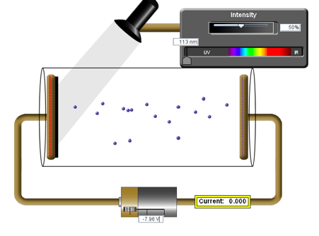

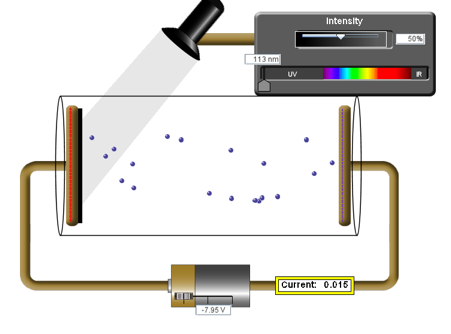

-7.96

200

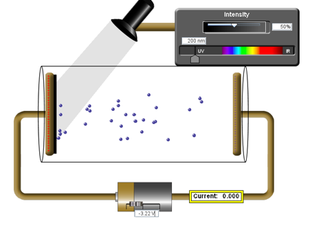

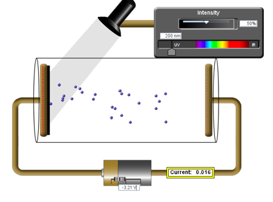

-3.22

280

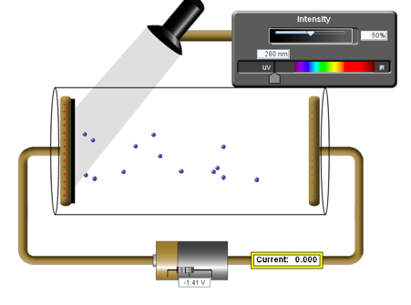

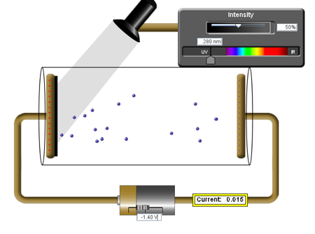

-1.41

378

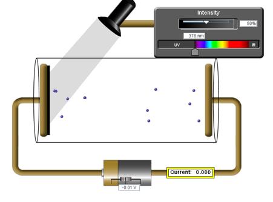

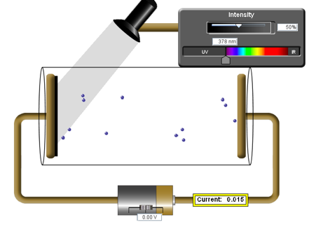

-0.01

La mediciones se pueden representar de la siguiente manera:

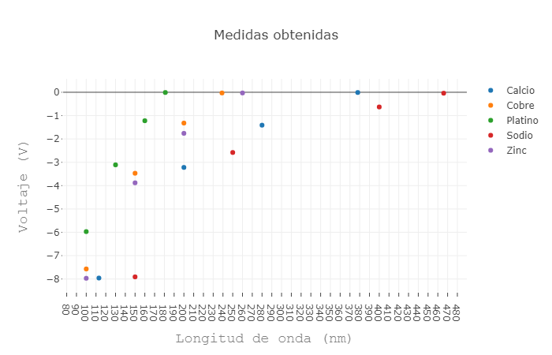

## ¿Para qué sirve UNPKG y porqué es uno de los servicios más usados de Internet (junto con jspm, ESM, cdnjs, jsdelivr, …)? ¿Qué son los CDN?

UNPKG es una CDN gratuita que distribuye automáticamente los paquetes públicos publicados en NMP (sistema de gestión de paquetes por defecto para node.js. Es un servicio muy utilizado ya que permite almacenar los archivos en cache y esto hace que sea muy rápido a lo que también hay que añadir que es un servicio gratuito.

CDN (Red de distribución de contenido). Es una red distribuida geográficamente de servidores proxy y sus centros de datos, surgieron a finales de los 90 para aliviar los cuellos de botella del rendimiento de internet. Sin una CDN los servidores de origen deben responder a todas las peticiones de los usuarios finales y esto genera un tráfico en la red con una gran carga y puede producir fallos, es por ello que los nodos CDN descargan el tráfico a los servidores de origen y mejoran la experiencia web ya que permiten una alta disponibilidad y un alto rendimiento.

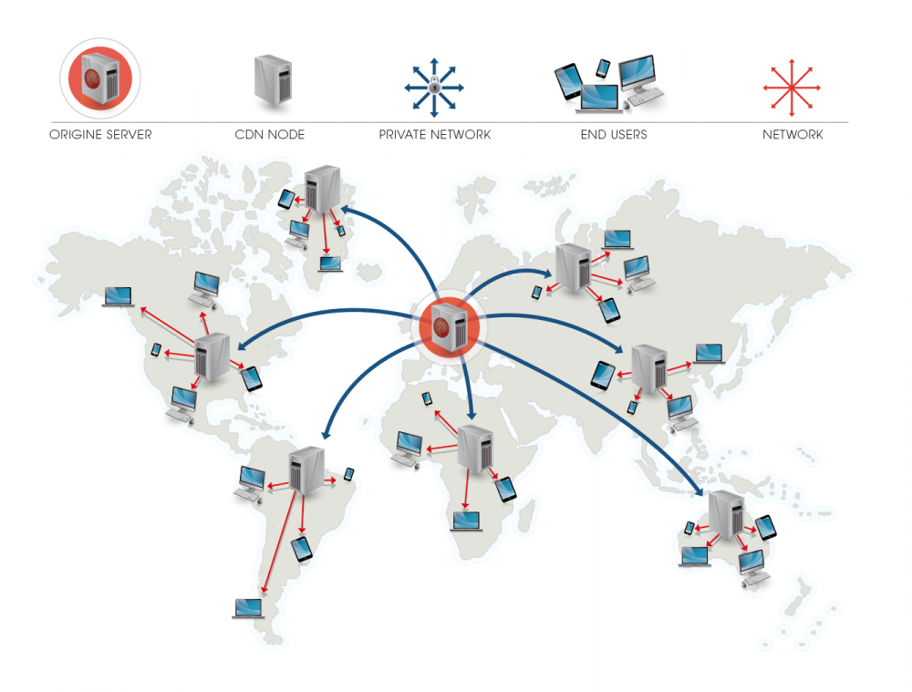

## Ajuste a una recta

var longitudes_de_onda_medidas = [150, 250, 400, 450].map(x => x*1e-9); // para pasar a metros var voltajes_medidos = [-5.86, -2.62, -0.59, -0.13]; // en voltios (voltaje de frenado)

Utilizamos tuplas para ajustar cada frecuencia con su voltaje de frenado.

inversa_de_longitudes_de_onda = longitudes_de_onda_medidas.map(lambda => 1/lambda );  
var datos_a_ajustar = voltajes_medidos.reduce((tuplas_longitud_onda_voltaje, b, i) => { tuplas_longitud_onda_voltaje.push([inversa_de_longitudes_de_onda[i], b]); return tuplas_longitud_onda_voltaje; }, []); console.log(datos_a_ajustar); // Verás que son tuplas de valores 1/lambda y voltajes

Ajustamos los datos a una recta.

```javascript
var regression = require('./regression.js');
var result = regression.linear(datos_a_ajustar, { precision: 15 });
var m = result.equation[0];  // pendiente
var b = result.equation[1];  // ordenada en origen
console.log('la pendiente es = ' + m + ' y la ordenada es = ' + b);
```

```
la pendiente es = -0.000001280640715 y la ordenada es = 2.626909417430555
```

## Representación gráfica de los datos

El último ejercicio consiste en representar gráficamente los datos experimentales y la recta obtenida.

```javascript
function Plotly(data, layout, $$) {
    $$ = $$ || global.$$;
    $$.mime({ "application/vnd.plotly.v1+json": { data: data, layout: layout } });
}
```

```javascript
voltajes_de_frenado_calculados = inversa_de_longitudes_de_onda.map(inversa_lambda => inversa_lambda * m + b);
```

```
[
  -5.910695349236111,
  -2.4956534425694445,
  -0.5746923700694451,
  -0.21895883812500028
]
```

```javascript
datos = [
  { x: inversa_de_longitudes_de_onda, y: voltajes_medidos, name: 'Datos experimentales' },
  { x: inversa_de_longitudes_de_onda, y: voltajes_de_frenado_calculados, name: 'Datos calculados tras ajuste' }
];

var layout = {
  title: 'Datos experimentales VS Datos calculados tras ajuste',
  xaxis: { title: 'voltajes (V)', titlefont: {
    family: 'Courier New, monospace', size: 18, color: '#7f7f7f' }
  },
  yaxis: {
    title: ' inversa longuitudes de onda (Hz)', titlefont: {
      family: 'Courier New, monospace', size: 18, color: '#7f7f7f' }
  }
};
Plotly(datos, layout);
```

la grafica de los valores obtenidos VS los datos calculador es la siguiente:

Zinc

[figure not shown]

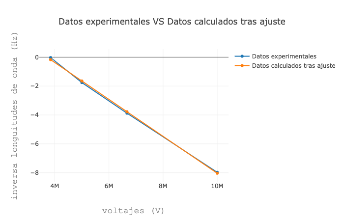

Cobre

Platino

[figure not shown]

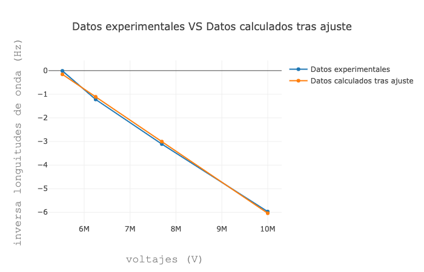

## Ejercicio premium

Modifica ahora el control de intensidad de la luz (el que va entre 0 y el 100%) para una longitud de onda de 100 nm y un metal a tu elección. ¿Qué le ocurre a la corriente que se mide con el amperímetro? Haz una gráfica que represente el amperaje medido respecto a dicha intensidad de luz. ¿Qué relación se observa?

En el caso del cobre se observa que a mayor intensidad mayor corriente, el siguiente codigo genera una grafica con los resultados:

```javascript
datos_Cu = [
{x: [10, 20, 30, 40, 50, 60, 70, 80, 90, 100],
y: [0.094, 0.178, 0.268, 0.351, 0.443, 0.535, 0.618, 0.703,
0.795, 0.882],
name: 'Cobre expuesto a 100nm',
marker: {
color: 'rgb(0, 0, 255)',
size: 6
},
line: {
color: 'rgb(0, 0, 255)',
dash: 'dashdot',
width: 1
}},
];
var layout_Cu = {
title: 'Cobre expuesto a 100nm',
xaxis: { title: 'Intensidad (%)',
titlefont: { family: 'Courier New, monospace', size: 16,
color: '#7f7f7f' }
},
yaxis: {
title: 'Amperios (A)', titlefont: {
family: 'Courier New, monospace', size: 16, color:
'#7f7f7f' }
}
};
Plotly(datos_Cu, layout_Cu);
```

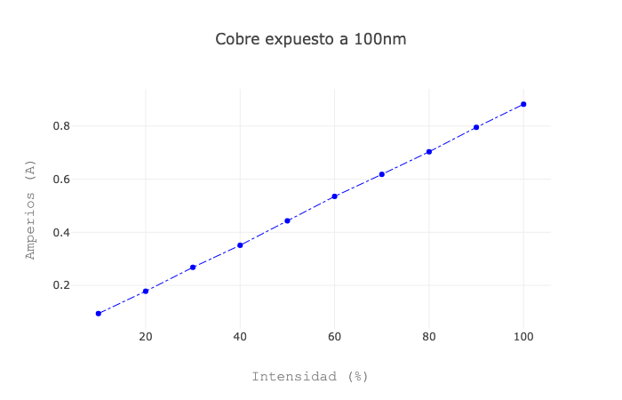

## Historia en torno al efecto fotoeléctrico

Desde que James Clerk Maxwell unifica el fenómeno de la electricidad y el magnetismo en 1864. Aparecen dos teorías, las que sostienen que el fenómeno se produce por ondas electromagnéticas como H. Herz y los que sostienen que se trata de partículas como Thomson. En 1905 Einstein introduce el concepto de cuanto y en 1915 Millakan corroborará experimentalmente las teorías de Einstein aunque su intención inicial era la de demostrar justo lo contrario.

Einstein era un alemán judío, por aquel entonces surge el movimiento nazi y muchos físicos partidarios del nacismo tratan de desacreditar el trabajo de Einstein por ser demasiado teórico hasta el punto de negársele varios años el nobel de física. El principal critico fue Philipp Lenard quien curiosamente realizo el estudio del que partio Einstein para realizar su investigación sobre el efecto fotoeléctrico por el cual finalmente obtuvo el nobel en 1921.

# Partícula en un campo magnético

## Planteamiento

Un electrón con una capacidad de trabajo de $72090×10^{−19}$ J orbita de manera perpendicular a un campo magnético de 3250 G. ¿Cuál es el radio de la órbita? ¿Y su frecuencia y periodo angular? ¿A qué velocidad va? Resuelve el mismo ejercicio para un antineutrón.

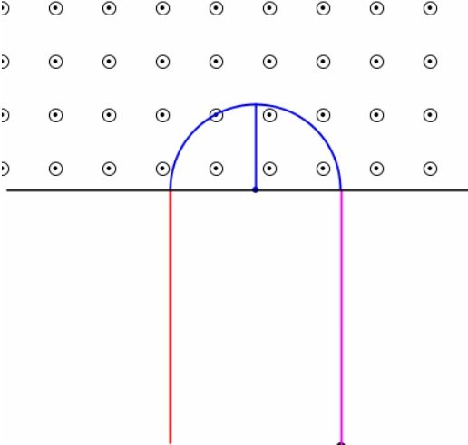

## Resolución

### Entorno

Lenguaje de programación Python y su librería sympy para así importar lo necesario en términos físicos para los cálculos según los datos que nos proporciona el planteamiento.

### Cálculo del radio

1.- Inicialmente tenemos que transformar los Gauss del campo magnético a la unidad del Sistema Internacional, el Tesla, para ello importamos lo siguiente:

- Gauss del Sistema Cegesimal
- El sistema de unidades Internacional
- La unidad densidad de flujo magnético

Asociamos la unidad Gauss a la densidad de flujo magnético del Sistema Internacional e importamos también la unidad Tesla, y ya con todo esto importado relacionamos la equivalencia de 1 Gauss con respecto al Tesla y creamos una variable con los Gauss del planteamiento

```python
from sympy.physics.units import Quantity

Gs = Quantity("Gauss")

from sympy.physics.units.systems import SI
from sympy.physics.units.systems.si import dimsys_SI

from sympy.physics.units import magnetic_flux_density

SI.set_quantity_dimension(Gs, magnetic_flux_density)

from sympy.physics.units import tesla

SI.set_quantity_scale_factor(Gs, 1E-4*tesla)

B = 3250 * Gs
```

Definimos también la capacidad de trabajo, la carga del electrón e importamos lo necesario para la resolución de ecuaciones

```python
from sympy.physics.units import joule

E = 72090E-19 * joule

from sympy import solve, symbols, pi, Eq

r = symbols("r_giro")

v = symbols("v_giro")

from sympy.physics.units import electronvolt
from sympy.physics.units import volt

q = 1*electronvolt/volt

from sympy.physics.units import speed_of_light as c
from sympy.physics.units import joule, electronvolt, convert_to

print("Equivalencia entre electronvoltios y Julios: ",convert_to(electronvolt, joule))
```

```
Equivalencia entre electronvoltios y Julios:  1.602176634e-19*joule
```

```python
m = 0.5 * 1E6 * electronvolt / c**2
print(m)
```

```
500000.0*electronvolt/speed_of_light**2
```

- Ecuación de Lorentz $$ F = q_e v_e B$$
  - Aplicación de la Ley de Newton $$F = \frac {m v^2}{r}$$
- Energía Cinética $$ E_c = \frac {1}{2}m v^2$$

Teniendo la energía cinética del electrón: $72090×10^{−19}$ J

```python
eq_lorentz = Eq(q*v*B, (m*v**2)/r)
eq_ecinetica = Eq(E, 0.5*m*v**2)
```

En base a las dos ecuaciones previas, despejamos las incógnitas v y r definidas anteriormente, y asignamos a la variable radio el resultado de la segunda incógnita

```python
solucion_v_r = solve([eq_ecinetica, eq_lorentz], [v, r])[1]

radio = solucion_v_r[1]
```

Realizamos la conversión a unidades de longitud del Sistema Internacional para obtener el radio en metros

```python
from sympy.physics.units import convert_to
from sympy.physics.units import meter, day

radio = convert_to(radio, [meter]).n(2)

print("Radio: ",radio)
```

```
Radio:  0.0022*meter
```

El periodo angular y la frecuencia son dos medidas relacionadas de manera inversa, por lo que siendo la fórmula del periodo angular (tiempo en que el electrón tarda en dar una vuelta entera): $$T = \frac {2 \pi r } {v} $$ Siendo la fórmula del radio: $$r = \frac{mv}{qB}$$ Por lo que sustituyendo el radio en el periodo: $$T = \frac {2 \pi m} {q B} $$ La frecuencia (vueltas por segundo) se podrá calcular como: $$f = \frac {1} {T} $$ Y la velocidad angular (ω): $$ω = 2πf $$ Siendo 2π la velocidad si se da una vuelta en un segundo expresado en radianes/segundo

```python
from sympy.physics.units import second
T = (2*pi.evalf()*m)/(q*B)
T=convert_to(T, second)
f = 1/T
w = 2*pi.evalf()*f
print ("Periodo angular: ", T)
print ("Frecuencia: ", f)
print ("Velocidad: ",w)
```

[output not shown]

```
Periodo angular:  1.07553638218902e-10*second
Frecuencia:  9297686406.15129/second
Velocidad:  58419086617.8932/second
```

### Antineutrón

Dado que un antineutrón tiene carga neta 0, no dispone de la propiedad necesaria para que el campo magnético interactúe con él, por lo que no tendrá efecto sobre el antineutrón y este no orbitará entorno al campo magnético.

### En el código anterior: ¿por qué indicamos que las dimensiones de la unidad gauss (definida por nosotros) son de densidad de flujo magnético (magnetic_flux_density)? ¿Por qué la carga del electrón se ha definido como electronvolt/volt?

La unidad de Gauss (G) es la unidad de la densidad del flujo magnético en el Sistema Cegesimal y tiene su equivalencia en el Sistema Internacional con el Tesla siguiendo la relación: $$1* G = 10^{−4}*T$$ A pesar de la prevalecencia a día de hoy del Sistema Internacional, la unidad de Gauss se sigue utilizando para medidas pequeñas como aquellas asociadas a los gradianes (entre otros), relacionados a su vez con la frecuencia angular.

La carga del electrón se ha definido como electronvolt/volt por la relación de equivalencia entre energía y masa dada por $E = mc^2$. Dado que el electronvolt es la energía obtenida por un electrón en su desplazamiento entre dos puntos cuando la diferencia de potencial del campo eléctrico es de 1 voltio. Por la relación que la relatividad da a la energía y la masa a través de electronvoltios, se puede obtener la masa del electrón.

## Tabla de valoración individual

Se os pide que incluyáis una tabla parecida a esta (cada uno). Podéis hacerlo en cualquiera de los dos documentos.

|  | Sí | No | A veces |
| --- | --- | --- | --- |
| Todos los miembros se han integrado al trabajo del grupo | X |  |  |
| Todos los miembros participan activamente | X |  |  |
| Todos los miembros respetan otras ideas aportadas | X |  |  |
| Todos los miembros participan en la elaboración del informe | X |  |  |
| Me he preocupado por realizar un trabajo cooperativo con mis compañeros | X |  |  |
| Señala si consideras que algún aspecto del trabajo en grupo no ha sido adecuado |  |  |  |